# Stock Price Analytics & Simulation

### Table of content

1. Exploratory Data Analysis
   1. Exploring the dataset
   2. Visualizing the target as continuous variable
   3. Visualizing the target as discrete variable
   4. Imbalanced data
2. Data Pre-processing
   1. Outliers detection
   2. Removing outliers
   3. Treating dates
   4. Scaling the dataset
   5. Visualizing each feature
   6. Seperating features & targets
3. Machine Learning Models - Sampling Classification models
   1. Support Vector Machine
   2. KNN
4. The distribution of historical stock prices return & Real time stock price simulation

```python
# Importing neccessary libraries
import numpy as np
import pandas as pd
from scipy.stats import norm
import scipy.stats as st

import matplotlib.pyplot as plt
import seaborn as sns
import plotly.express as px

import time
import datetime as dt

import warnings
warnings.filterwarnings('ignore')
```

```python
dataset = pd.read_csv("SafaricomHistoricalPrices.csv")
#dataset = pd.read_csv("CoopbankHistoricalPrices.csv")
#dataset = pd.read_csv("EABLHistoricalPrices.csv")
#dataset = pd.read_csv("EquityHistoricalPrices.csv")
#dataset = pd.read_csv("KcbHistoricalPrices.csv")
```

## 1.0 Exploratory Data Analysis

### 1.1 Exploring the dataset

```python
dataset.head()
```

|  | Date | Open | High | Low | Close | Volume |
| --- | --- | --- | --- | --- | --- | --- |
| 0 | 05/26/23 | 15.30 | 15.30 | 14.95 | 15.05 | 12117800 |
| 1 | 05/25/23 | 15.35 | 15.35 | 15.00 | 15.05 | 22905400 |
| 2 | 05/24/23 | 15.35 | 15.35 | 15.00 | 15.25 | 8640900 |
| 3 | 05/23/23 | 15.45 | 15.45 | 14.95 | 15.30 | 2738400 |
| 4 | 05/22/23 | 15.45 | 15.45 | 14.90 | 15.05 | 2271800 |

```python
dataset.shape
```

```
(3745, 6)
```

```python
print("The dataset has {} features & {} samples.".format(dataset.shape[1], dataset.shape[0]))
```

```
The dataset has 6 features & 3745 samples.
```

```python
# Descriptive statistics
dataset.describe()
```

|  | Open | High | Low | Close | Volume |
| --- | --- | --- | --- | --- | --- |
| count | 3745.000000 | 3745.000000 | 3745.000000 | 3745.000000 | 3.745000e+03 |
| mean | 17.225207 | 17.433378 | 16.994983 | 17.185327 | 1.117138e+07 |
| std | 11.729345 | 11.869955 | 11.553650 | 11.695497 | 1.534974e+07 |
| min | 2.550000 | 2.550000 | 2.550000 | 2.550000 | 1.028000e+05 |
| 25% | 5.250000 | 5.250000 | 5.250000 | 5.250000 | 3.607600e+06 |
| 50% | 16.100000 | 16.300000 | 15.950000 | 16.100000 | 7.263900e+06 |
| 75% | 27.500000 | 27.950000 | 27.100000 | 27.500000 | 1.327670e+07 |
| max | 45.000000 | 45.250000 | 44.000000 | 44.950000 | 4.163831e+08 |

```python
dataset.describe(include = 'all')
```

|  | Date | Open | High | Low | Close | Volume |
| --- | --- | --- | --- | --- | --- | --- |
| count | 3745 | 3745.000000 | 3745.000000 | 3745.000000 | 3745.000000 | 3.745000e+03 |
| unique | 3745 | NaN | NaN | NaN | NaN | NaN |
| top | 05/26/23 | NaN | NaN | NaN | NaN | NaN |
| freq | 1 | NaN | NaN | NaN | NaN | NaN |
| mean | NaN | 17.225207 | 17.433378 | 16.994983 | 17.185327 | 1.117138e+07 |
| std | NaN | 11.729345 | 11.869955 | 11.553650 | 11.695497 | 1.534974e+07 |
| min | NaN | 2.550000 | 2.550000 | 2.550000 | 2.550000 | 1.028000e+05 |
| 25% | NaN | 5.250000 | 5.250000 | 5.250000 | 5.250000 | 3.607600e+06 |
| 50% | NaN | 16.100000 | 16.300000 | 15.950000 | 16.100000 | 7.263900e+06 |
| 75% | NaN | 27.500000 | 27.950000 | 27.100000 | 27.500000 | 1.327670e+07 |
| max | NaN | 45.000000 | 45.250000 | 44.000000 | 44.950000 | 4.163831e+08 |

```python
dataset.info()
```

```
<class 'pandas.core.frame.DataFrame'>
RangeIndex: 3745 entries, 0 to 3744
Data columns (total 6 columns):
 #   Column  Non-Null Count  Dtype
---  ------  --------------  -----
 0   Date    3745 non-null   object
 1   Open    3745 non-null   float64
 2   High    3745 non-null   float64
 3   Low     3745 non-null   float64
 4   Close   3745 non-null   float64
 5   Volume  3745 non-null   int64
dtypes: float64(4), int64(1), object(1)
memory usage: 175.7+ KB
```

```python
# Check for missing values in the dataset
# In this case, we have no missing values
dataset.isna().sum()
```

```
Date      0
Open      0
High      0
Low       0
Close     0
Volume    0
dtype: int64
```

```python
# Unique values in the classes of the features
dataset.nunique()
```

```
Date      3745
Open       649
High       638
Low        638
Close      686
Volume    3708
dtype: int64
```

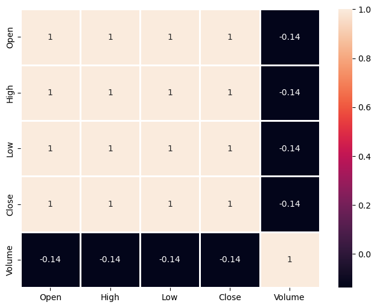

```python
# Heatmap to check for correlation between features.
# This will later help one to eliminate highly correlated values.
plt.figure(figsize = (8,6))

corr = dataset.corr()

sns.heatmap(data = corr, annot = True, fmt = '0.2g', linewidth = 1)
plt.show()
```

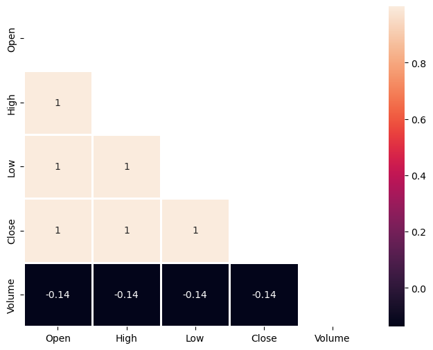

```python
# Checking multicolinearity between the features
plt.figure(figsize = (8,6))

corr = dataset.corr()
mask = np.triu(np.ones_like(corr, dtype = bool))

sns.heatmap(data = corr, mask = mask, annot = True, fmt = '0.2g', linewidth = 1)
plt.show()
```

```python
# There is a very strong correlation between open, high, low and close stock prices. Drop Open,
# high and low. Be left with close and volumes
```

```python
# Before dropping the correlated columns
dataset.head()
```

|  | Date | Open | High | Low | Close | Volume |
| --- | --- | --- | --- | --- | --- | --- |
| 0 | 05/26/23 | 15.30 | 15.30 | 14.95 | 15.05 | 12117800 |
| 1 | 05/25/23 | 15.35 | 15.35 | 15.00 | 15.05 | 22905400 |
| 2 | 05/24/23 | 15.35 | 15.35 | 15.00 | 15.25 | 8640900 |
| 3 | 05/23/23 | 15.45 | 15.45 | 14.95 | 15.30 | 2738400 |
| 4 | 05/22/23 | 15.45 | 15.45 | 14.90 | 15.05 | 2271800 |

```python
dataset.drop(columns = ['Open','High','Low'], inplace = True, axis = 1)
```

```python
dataset.shape
```

```
(3745, 3)
```

```python
dataset.head()
```

|  | Date | Close | Volume |
| --- | --- | --- | --- |
| 0 | 05/26/23 | 15.05 | 12117800 |
| 1 | 05/25/23 | 15.05 | 22905400 |
| 2 | 05/24/23 | 15.25 | 8640900 |
| 3 | 05/23/23 | 15.30 | 2738400 |
| 4 | 05/22/23 | 15.05 | 2271800 |

```python
dataset.nunique()
```

```
Date      3745
Close      686
Volume    3708
dtype: int64
```

```python
dataset.head()
```

|  | Date | Close | Volume |
| --- | --- | --- | --- |
| 0 | 05/26/23 | 15.05 | 12117800 |
| 1 | 05/25/23 | 15.05 | 22905400 |
| 2 | 05/24/23 | 15.25 | 8640900 |
| 3 | 05/23/23 | 15.30 | 2738400 |
| 4 | 05/22/23 | 15.05 | 2271800 |

```python
# How to get returns of closing stock prices
dataset['Daily_return'] = np.log(dataset['Close']/dataset['Close'].shift())
```

```python
dataset.head()
```

|  | Date | Close | Volume | Daily_return |
| --- | --- | --- | --- | --- |
| 0 | 05/26/23 | 15.05 | 12117800 | NaN |
| 1 | 05/25/23 | 15.05 | 22905400 | 0.000000 |
| 2 | 05/24/23 | 15.25 | 8640900 | 0.013202 |
| 3 | 05/23/23 | 15.30 | 2738400 | 0.003273 |
| 4 | 05/22/23 | 15.05 | 2271800 | -0.016475 |

```python
dataset.shape
```

```
(3745, 4)
```

```python
# There is one missing number in the dataset
dataset.isna().sum()
```

```
Date            0
Close           0
Volume          0
Daily_return    1
dtype: int64
```

```python
# Since the log of daily returns are normally distributed,
# we replace missing numbers with mean
dataset.fillna(dataset['Daily_return'].mean(), inplace = True)
```

```python
# Confirming the missing value has been removed
dataset.isna().sum()
```

```
Date            0
Close           0
Volume          0
Daily_return    0
dtype: int64
```

```python
dataset.head()
```

|  | Date | Close | Volume | Daily_return |
| --- | --- | --- | --- | --- |
| 0 | 05/26/23 | 15.05 | 12117800 | -0.000191 |
| 1 | 05/25/23 | 15.05 | 22905400 | 0.000000 |
| 2 | 05/24/23 | 15.25 | 8640900 | 0.013202 |
| 3 | 05/23/23 | 15.30 | 2738400 | 0.003273 |
| 4 | 05/22/23 | 15.05 | 2271800 | -0.016475 |

```python
returns = dataset['Daily_return']
```

```python
returns.head()
```

```
0   -0.000191
1    0.000000
2    0.013202
3    0.003273
4   -0.016475
Name: Daily_return, dtype: float64
```

### 1.2 Visualizing target as a continuous variable.

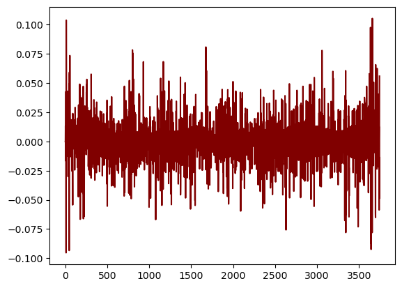

```python
# Visualizing flactuation of changes in daily returns
plt.plot(returns, color = 'maroon')
plt.show()
```

#### We see that log of changes in stock price daily returns are approx normal distributed.

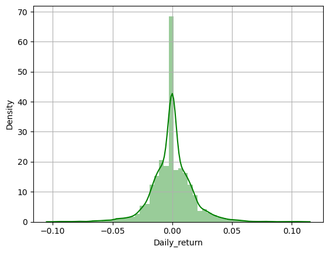

```python
sns.distplot(returns, hist = True, color = 'green')
plt.grid(True)
plt.show()
```

### 1.3 Visualizing target as a discrete variable.

#### Note: We wish to look at up_move, down_move, no_move of the stock price

Let up_move be denoted by 1, down_move, -1 and no_move, 0

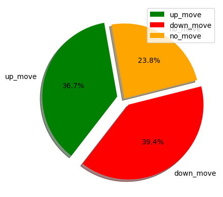

```python
stock_motion = list()
motion_data = list()
for i in list(returns):
    if i > 0:
        stock_motion.append(1)
    elif i < 0:
        stock_motion.append(-1)
    else:
        stock_motion.append(0)
#stock_motion

motion_data.append(stock_motion.count(1))
motion_data.append(stock_motion.count(-1))
motion_data.append(stock_motion.count(0))


stock_state = ['up_move', 'down_move', 'no_move']

mycolor = ('green', 'red', 'orange')
myexplode = [0.10, 0.10, 0.00]
plt.pie(motion_data, labels = stock_state, colors = mycolor, explode = myexplode,
       shadow = True, startangle = 100, autopct = '%1.1f%%')
plt.legend()
plt.show()
```

#### Quicky, historical performance shows that we have more down_moves than either up or no_moves.

### 1.4 Imbalance data

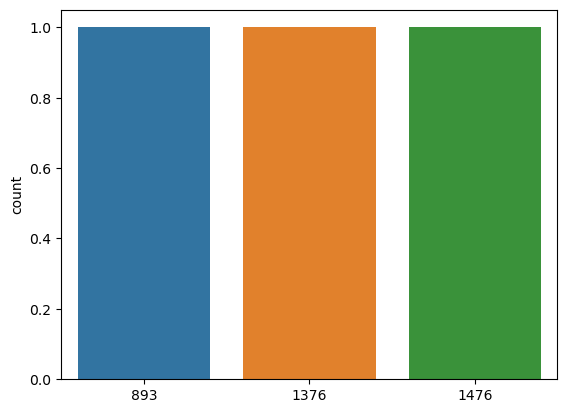

```python
motion_data
sns.countplot(x = motion_data)
plt.show()
```

#### Inference: The dataset appears not to be very much imbalanced

## 2.0 Data Pre-processing

### 2.1 Outliers Detection

```python
# Numerical data
numerical_data = dataset.select_dtypes(include = ['float64', 'int64'])
numerical_data
```

|  | Close | Volume | Daily_return |
| --- | --- | --- | --- |
| 0 | 15.05 | 12117800 | -0.000191 |
| 1 | 15.05 | 22905400 | 0.000000 |
| 2 | 15.25 | 8640900 | 0.013202 |
| 3 | 15.30 | 2738400 | 0.003273 |
| 4 | 15.05 | 2271800 | -0.016475 |
| ... | ... | ... | ... |
| 3740 | 7.45 | 250901500 | -0.058649 |
| 3741 | 7.35 | 131243703 | -0.013514 |
| 3742 | 7.00 | 183494797 | -0.048790 |
| 3743 | 6.95 | 127305797 | -0.007168 |
| 3744 | 7.35 | 416383094 | 0.055959 |

3745 rows × 3 columns

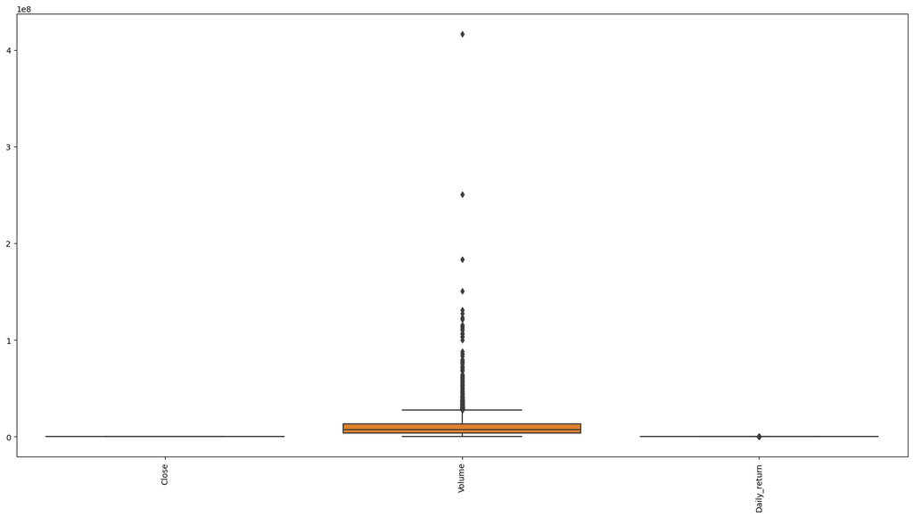

```python
# Outliers detection
plt.figure(figsize=(20,10))
sns.boxplot(numerical_data)
plt.xticks(rotation=90)
plt.show()
```

#### Note that volume has outliers

### 2.2 Removing Outliers from the dataset

```python
# Dataset before removal of outliers
dataset.shape
```

```
(3745, 4)
```

```python
# Removing outliers from the dataset
num_col = ['Volume']
Q1 = dataset[num_col].quantile(0.25) # lower quartile
Q3 = dataset[num_col].quantile(0.75) # upper quartile
IQR = Q3 - Q1 # interquartile range
lb = Q1 - 1.5*IQR # lower boundary
hb = Q3 + 1.5*IQR # higher boundary
for i in num_col:
    dataset_clean = dataset[(dataset[i]>= lb[i]) & (dataset[i] <= hb[i])]
```

```python
# Dataset after removal of outliers
dataset_clean.shape
```

```
(3481, 4)
```

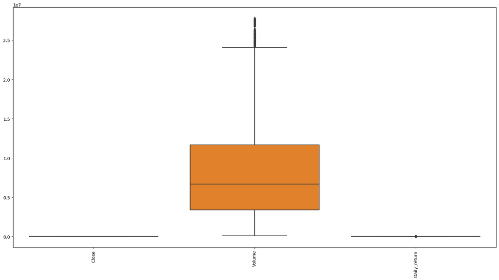

```python
# Test  for outliers visually
plt.figure(figsize=(20,10))
sns.boxplot(dataset_clean)
plt.xticks(rotation=90)
plt.show()
```

#### Inference: We have significantly reduced the outliers

```python
dataset_clean.info()
```

```
<class 'pandas.core.frame.DataFrame'>
Int64Index: 3481 entries, 0 to 3725
Data columns (total 4 columns):
 #   Column        Non-Null Count  Dtype
---  ------        --------------  -----
 0   Date          3481 non-null   object
 1   Close         3481 non-null   float64
 2   Volume        3481 non-null   int64
 3   Daily_return  3481 non-null   float64
dtypes: float64(2), int64(1), object(1)
memory usage: 136.0+ KB
```

```python
# Suppose we did not remove the outliers
#dataset_clean = dataset.copy()
```

### 2.3 Treating Dates

```python
categorical_dataset = dataset_clean.select_dtypes(include = 'object')
categorical_dataset
```

|  | Date |
| --- | --- |
| 0 | 05/26/23 |
| 1 | 05/25/23 |
| 2 | 05/24/23 |
| 3 | 05/23/23 |
| 4 | 05/22/23 |
| ... | ... |
| 3716 | 07/17/08 |
| 3719 | 07/14/08 |
| 3720 | 07/11/2008 |
| 3723 | 07/08/2008 |
| 3725 | 07/04/2008 |

3481 rows × 1 columns

```python
categorical_dataset['Date']
```

```
0         05/26/23
1         05/25/23
2         05/24/23
3         05/23/23
4         05/22/23
           ...
3716      07/17/08
3719      07/14/08
3720    07/11/2008
3723    07/08/2008
3725    07/04/2008
Name: Date, Length: 3481, dtype: object
```

```python
# Seperating dates by day, Month and Year
categorical_dataset['Date'] = pd.to_datetime(categorical_dataset['Date'])
categorical_dataset['Year'] = categorical_dataset['Date'].dt.year
categorical_dataset['Month'] = categorical_dataset['Date'].dt.month
categorical_dataset['Day'] = categorical_dataset['Date'].dt.day
categorical_dataset.drop('Date', axis = 1, inplace = True)
```

```python
categorical_dataset.head()
```

|  | Year | Month | Day |
| --- | --- | --- | --- |
| 0 | 2023 | 5 | 26 |
| 1 | 2023 | 5 | 25 |
| 2 | 2023 | 5 | 24 |
| 3 | 2023 | 5 | 23 |
| 4 | 2023 | 5 | 22 |

```python
# concatenating dates and numerical dataset
# Get the numerical values first
numerical_data_clean = dataset_clean.select_dtypes(include = ['float64', 'int64'])
unscaled_dataset = pd.concat([categorical_dataset.reset_index(),
                              numerical_data_clean.reset_index()], axis = 1)
#numerical_data_clean.head()
#numerical_data_clean.shape
unscaled_dataset.head()
```

|  | index | Year | Month | Day | index | Close | Volume | Daily_return |
| --- | --- | --- | --- | --- | --- | --- | --- | --- |
| 0 | 0 | 2023 | 5 | 26 | 0 | 15.05 | 12117800 | -0.000191 |
| 1 | 1 | 2023 | 5 | 25 | 1 | 15.05 | 22905400 | 0.000000 |
| 2 | 2 | 2023 | 5 | 24 | 2 | 15.25 | 8640900 | 0.013202 |
| 3 | 3 | 2023 | 5 | 23 | 3 | 15.30 | 2738400 | 0.003273 |
| 4 | 4 | 2023 | 5 | 22 | 4 | 15.05 | 2271800 | -0.016475 |

```python
unscaled_dataset.shape
```

```
(3481, 8)
```

### 2.4 Scaling the dataset

```python
# Scaling the dataset
from sklearn.preprocessing import StandardScaler

scaler = StandardScaler()
scaled_data = scaler.fit_transform(unscaled_dataset)
```

```python
scaled_dataset = pd.DataFrame(data = scaled_data, columns = unscaled_dataset.columns)
scaled_dataset .head()
```

|  | index | Year | Month | Day | index | Close | Volume | Daily_return |
| --- | --- | --- | --- | --- | --- | --- | --- | --- |
| 0 | -1.695450 | 1.715117 | -0.437008 | 1.157986 | -1.695450 | -0.221255 | 0.621690 | -0.006453 |
| 1 | -1.694524 | 1.715117 | -0.437008 | 1.043659 | -1.694524 | -0.221255 | 2.366797 | 0.004979 |
| 2 | -1.693597 | 1.715117 | -0.437008 | 0.929332 | -1.693597 | -0.204317 | 0.059233 | 0.793388 |
| 3 | -1.692670 | 1.715117 | -0.437008 | 0.815005 | -1.692670 | -0.200082 | -0.895613 | 0.200466 |
| 4 | -1.691743 | 1.715117 | -0.437008 | 0.700677 | -1.691743 | -0.221255 | -0.971095 | -0.978916 |

```python
scaled_dataset.drop('index', axis = 1, inplace = True)
```

```python
scaled_dataset.head()
```

|  | Year | Month | Day | Close | Volume | Daily_return |
| --- | --- | --- | --- | --- | --- | --- |
| 0 | 1.715117 | -0.437008 | 1.157986 | -0.221255 | 0.621690 | -0.006453 |
| 1 | 1.715117 | -0.437008 | 1.043659 | -0.221255 | 2.366797 | 0.004979 |
| 2 | 1.715117 | -0.437008 | 0.929332 | -0.204317 | 0.059233 | 0.793388 |
| 3 | 1.715117 | -0.437008 | 0.815005 | -0.200082 | -0.895613 | 0.200466 |
| 4 | 1.715117 | -0.437008 | 0.700677 | -0.221255 | -0.971095 | -0.978916 |

```python
scaled_dataset.shape
final_dataset = scaled_dataset.copy()
```

### 2.5 Visualizing distribution of each feature

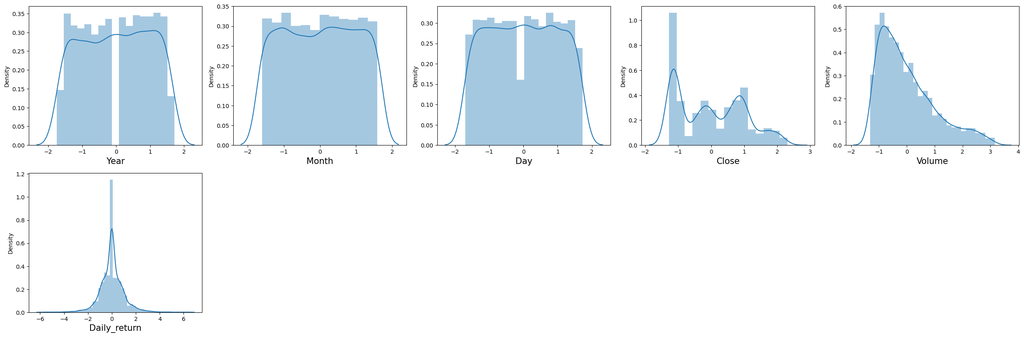

```python
plt.figure(figsize = (25,20))
plotnumber = 1

for col in final_dataset.columns:
    if plotnumber <= 6:
        ax = plt.subplot(5, 5, plotnumber)
        sns.distplot(final_dataset[col])
        plt.xlabel(col, fontsize = 15)
    plotnumber += 1
plt.tight_layout()
plt.show()
```

#### The distributions look okay...

### 2.6 Seperating features and target

```python
final_dataset.head()
```

|  | Year | Month | Day | Close | Volume | Daily_return |
| --- | --- | --- | --- | --- | --- | --- |
| 0 | 1.715117 | -0.437008 | 1.157986 | -0.221255 | 0.621690 | -0.006453 |
| 1 | 1.715117 | -0.437008 | 1.043659 | -0.221255 | 2.366797 | 0.004979 |
| 2 | 1.715117 | -0.437008 | 0.929332 | -0.204317 | 0.059233 | 0.793388 |
| 3 | 1.715117 | -0.437008 | 0.815005 | -0.200082 | -0.895613 | 0.200466 |
| 4 | 1.715117 | -0.437008 | 0.700677 | -0.221255 | -0.971095 | -0.978916 |

```python
y = final_dataset['Daily_return']
X = final_dataset.drop('Daily_return', axis = 1)
y.shape
```

```
(3481,)
```

```python
y.head()
```

```
0   -0.006453
1    0.004979
2    0.793388
3    0.200466
4   -0.978916
Name: Daily_return, dtype: float64
```

```python
X.shape
```

```
(3481, 5)
```

```python
X.head()
```

|  | Year | Month | Day | Close | Volume |
| --- | --- | --- | --- | --- | --- |
| 0 | 1.715117 | -0.437008 | 1.157986 | -0.221255 | 0.621690 |
| 1 | 1.715117 | -0.437008 | 1.043659 | -0.221255 | 2.366797 |
| 2 | 1.715117 | -0.437008 | 0.929332 | -0.204317 | 0.059233 |
| 3 | 1.715117 | -0.437008 | 0.815005 | -0.200082 | -0.895613 |
| 4 | 1.715117 | -0.437008 | 0.700677 | -0.221255 | -0.971095 |

```python
stock_motion = list()
motion_data = list()
for i in list(y):
    if i > 0:
        stock_motion.append(1)
    elif i < 0:
        stock_motion.append(-1)
    else:
        stock_motion.append(0)
#stock_motion

motion_data.append(stock_motion.count(1))
motion_data.append(stock_motion.count(-1))
motion_data.append(stock_motion.count(0))
```

```python
#motion_data
y = stock_motion.copy()
```

## 3.0 Machine Learning Models - Classification Models

```python
# Splitting data into training and testing set
from sklearn.model_selection import train_test_split

X_train, X_test, y_train, y_test = train_test_split(X, y, test_size = 0.25)
```

### 3.1 Support Vector Machine

```python
from sklearn.svm import SVC

svc = SVC() # Here,  we are instantiating the class
svc.fit(X_train, y_train) # Here, we are training the model
y_pred = svc.predict(X_test)
```

```python
# Accuracy_score, confusion_matrix and classification_report
from sklearn.metrics import accuracy_score, confusion_matrix, classification_report

svc_train_acc = accuracy_score(y_train, svc.predict(X_train))
svc_test_acc = accuracy_score(y_test, y_pred)

print(f"Trainig accuracy of Support Vector Classifier is : {svc_train_acc}")
print(f"Test accuracy of Support Vector Classifier is : {svc_test_acc}")

print(confusion_matrix(y_test, y_pred))
print(classification_report(y_test, y_pred))
```

```
Trainig accuracy of Support Vector Classifier is : 0.6134099616858237
Test accuracy of Support Vector Classifier is : 0.6142365097588978
[[ 11 328]
 [  8 524]]
              precision    recall  f1-score   support

          -1       0.58      0.03      0.06       339
           1       0.62      0.98      0.76       532

    accuracy                           0.61       871
   macro avg       0.60      0.51      0.41       871
weighted avg       0.60      0.61      0.49       871
```

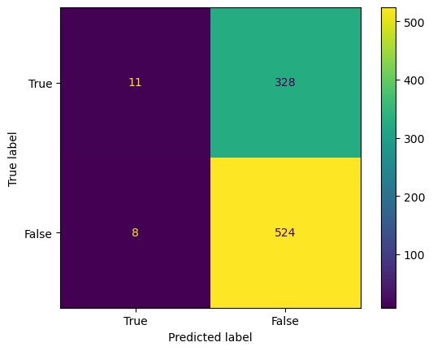

```python
# Plotting a confussion matrix with sklearn
from sklearn.metrics import ConfusionMatrixDisplay

conf_matrix = confusion_matrix(y_test, y_pred)
vis = ConfusionMatrixDisplay(confusion_matrix = conf_matrix, display_labels = ['True', 'False'])

vis.plot()
plt.show()
```

### 3.2 KNN

```python
from sklearn.neighbors import KNeighborsClassifier

knn = KNeighborsClassifier(n_neighbors = 30) # instantiating the model
knn.fit(X_train, y_train) # training the model

y_pred = knn.predict(X_test) # using the model for prediction
```

```python
# accuracy_score, confusion_matrix and classification_report
from sklearn.metrics import accuracy_score, confusion_matrix, classification_report

knn_train_acc = accuracy_score(y_train, knn.predict(X_train))
knn_test_acc = accuracy_score(y_test, y_pred)

print(f"Training accuracy of KNN is : {knn_train_acc}")
print(f"Test accuracy of KNN is : {knn_test_acc}")

print(confusion_matrix(y_test, y_pred))
print(classification_report(y_test, y_pred))
```

```
Training accuracy of KNN is : 0.6272030651340996
Test accuracy of KNN is : 0.5958668197474167
[[ 94 245]
 [107 425]]
              precision    recall  f1-score   support

          -1       0.47      0.28      0.35       339
           1       0.63      0.80      0.71       532

    accuracy                           0.60       871
   macro avg       0.55      0.54      0.53       871
weighted avg       0.57      0.60      0.57       871
```

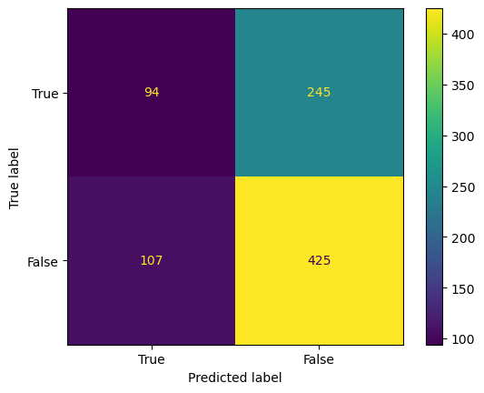

```python
# Plotting a confussion matrix with sklearn
from sklearn.metrics import ConfusionMatrixDisplay

conf_matrix = confusion_matrix(y_test, y_pred)
vis = ConfusionMatrixDisplay(confusion_matrix = conf_matrix, display_labels = ['True', 'False'])

vis.plot()
plt.show()
```

### Inference: We've sampled two models and seen that we cannot use classification models to predict stock prices returns.

## 4.0 The distribution of historical stock price returns & Realtime stock price simulation

```python
plt.style.use('ggplot')
```

```python
%matplotlib notebook
plt.rcParams['animation.html'] = 'jshtml'
```

```python
drift = np.mean(returns)
drift
```

```
-0.00019142031997065596
```

```python
volatility = np.std(returns)
volatility
```

```
0.017169931810059307
```

```python
# From the drift & volatility, get the probability that the stock price will go up in the next move?
```

```python
from scipy.stats import norm
```

```python
#print(norm.ppf(0.975)) # Gives z_value when given probability
```

```python
#print(norm.cdf(1.96)) # Gives probability when given z value
```

```python
print("Probability that stock price will go up is {}".format(norm.cdf(drift/volatility)))
```

```
Probability that stock price will go up is 0.49555245309568513
```

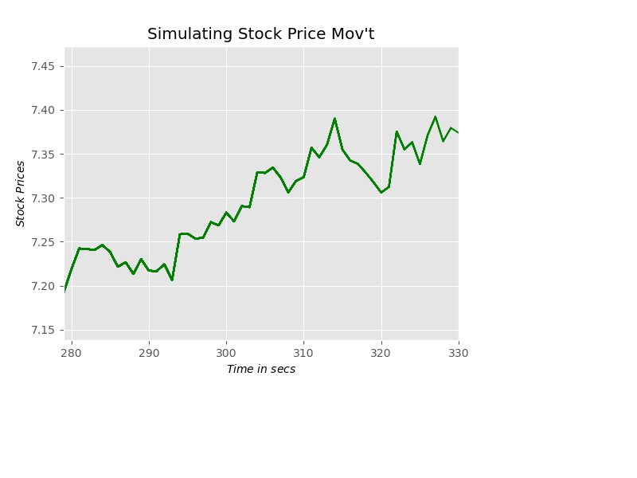

```python
fig = plt.figure()
ax = fig.add_subplot(111)
plt.title("Simulating Stock Price Mov't")
plt.xlabel("$Time$ $in$ $secs$")
plt.ylabel("$Stock$ $Prices$")
plt.grid(True)
fig.show()
```

```python
#current_share_price = dataset['Close'][3744]
current_share_price = dataset['Close'][len(dataset) - 1]
drft = drift
vol = volatility
i = 1
x, y = [], []
# y[0] = current_share_price
while True:
    rnd = np.random.random()
    S_1 = current_share_price*np.exp((drft*(1/52))+(vol*np.random.normal(0,1,1)[0]*np.sqrt(1/52)))
    x.append(i)
    y.append(S_1)

    ax.plot(x, y, color='green')
    fig.canvas.draw()

    ax.set_xlim(left=max(0,i-50), right=i+1)

    time.sleep(0.1)
    current_share_price = S_1
    i += 1
```